# Peer-graded Assignment: Statistical Inference Course Project

Alejandro Coy

2019-02-15

# Peer-graded Assignment: Statistical Inference Course Project

The project consists of two parts:

1. A simulation exercise.
2. Basic inferential data analysis.

## Part 1: Simulation Excercise :

In this project you will investigate the exponential distribution in R and compare it with the Central Limit Theorem. The exponential distribution can be simulated in R with rexp(n, lambda) where lambda is the rate parameter. The mean of exponential distribution is 1/lambda and the standard deviation is also 1/lambda. Set lambda = 0.2 for all of the simulations. You will investigate the distribution of averages of 40 exponentials. Note that you will need to do a thousand simulations.

### Show the sample mean and compare it to the theoretical mean of the distribution.

Theoretical Mean of distribution is 1/ lambda if lmabda is 0.2, the theoretical mean is 5

```r
set.seed(150)
lambda = 0.2
n = 40 #number of exponentials
n_simulations =1000

exp_mean = NULL
for(i in 1:n_simulations){
  exp_mean = c(exp_mean,mean(rexp(n,lambda)))
}
mean(exp_mean)
```

```
## [1] 5.00215
```

### Show how variable the sample is (via variance) and compare it to the theoretical variance of the distribution.

```r
theo_variance <- 1/lambda/sqrt(n)
variance_exp <- var(exp_mean)
variance_exp
```

```
## [1] 0.6498806
```

```r
theo_variance
```

```
## [1] 0.7905694
```

In this case the simulation is a little further.

### Show that the distribution is approximately normal.

To probe normality the exp_mean could be plotted in a histrogram

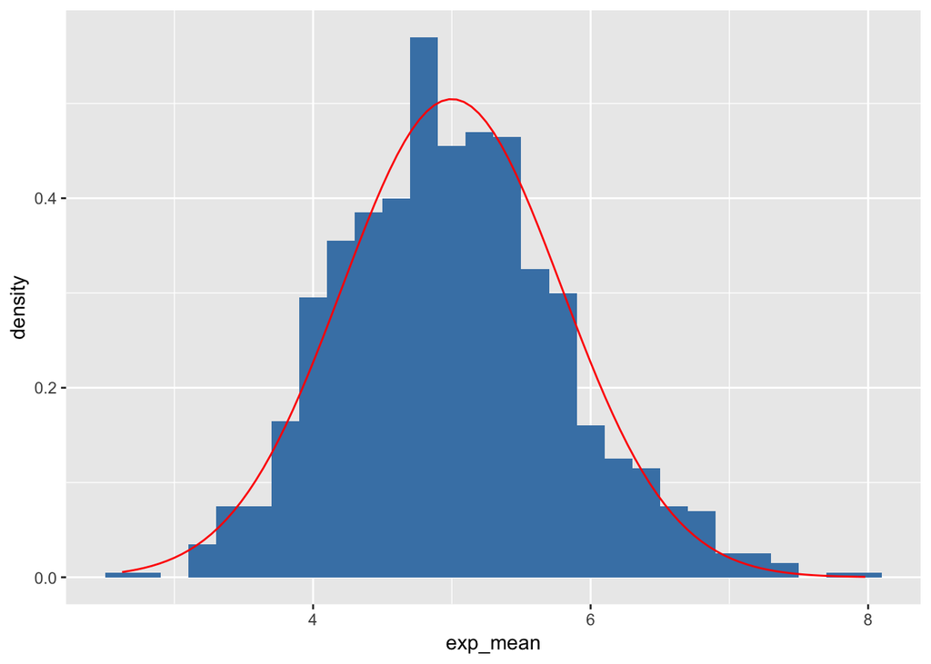

```r
library(ggplot2)

data <- data.frame(exp_mean,n)
ggplot(data = data,aes(exp_mean))+
  geom_histogram(aes(y=..density..),fill = "steelBlue",binwidth = 0.2)+
  stat_function(fun = dnorm,args= list(mean=1/lambda,sd=1/lambda/sqrt(40)),color ="red")
```

## Part 2: Basic inferential data analysis. :

The datased is imported and basic data information is obtained with the following functions:

```r
library(datasets)
library(dplyr)
```

```r
library(ggplot2)
data <- ToothGrowth
glimpse(data)
```

```
## Observations: 60
## Variables: 3
## $ len  <dbl> 4.2, 11.5, 7.3, 5.8, 6.4, 10.0, 11.2, 11.2, 5.2, 7.0, 16.5,…
## $ supp <fct> VC, VC, VC, VC, VC, VC, VC, VC, VC, VC, VC, VC, VC, VC, VC,…
## $ dose <dbl> 0.5, 0.5, 0.5, 0.5, 0.5, 0.5, 0.5, 0.5, 0.5, 0.5, 1.0, 1.0,…
```

```r
str(data)
```

```
## 'data.frame':    60 obs. of  3 variables:
##  $ len : num  4.2 11.5 7.3 5.8 6.4 10 11.2 11.2 5.2 7 ...
##  $ supp: Factor w/ 2 levels "OJ","VC": 2 2 2 2 2 2 2 2 2 2 ...
##  $ dose: num  0.5 0.5 0.5 0.5 0.5 0.5 0.5 0.5 0.5 0.5 ...
```

```r
head(data)
```

```
##    len supp dose
## 1  4.2   VC  0.5
## 2 11.5   VC  0.5
## 3  7.3   VC  0.5
## 4  5.8   VC  0.5
## 5  6.4   VC  0.5
## 6 10.0   VC  0.5
```

### Sumarry of the data:

Description

The response is the length of odontoblasts (cells responsible for tooth growth) in 60 guinea pigs. Each animal received one of three dose levels of vitamin C (0.5, 1, and 2 mg/day) by one of two delivery methods, orange juice or ascorbic acid (a form of vitamin C and coded as VC).

Usage

ToothGrowth Format

A data frame with 60 observations on 3 variables.

[,1] len numeric Tooth length [,2] supp factor Supplement type (VC or OJ). [,3] dose numeric Dose in milligrams/day

### Exploratory data analysis

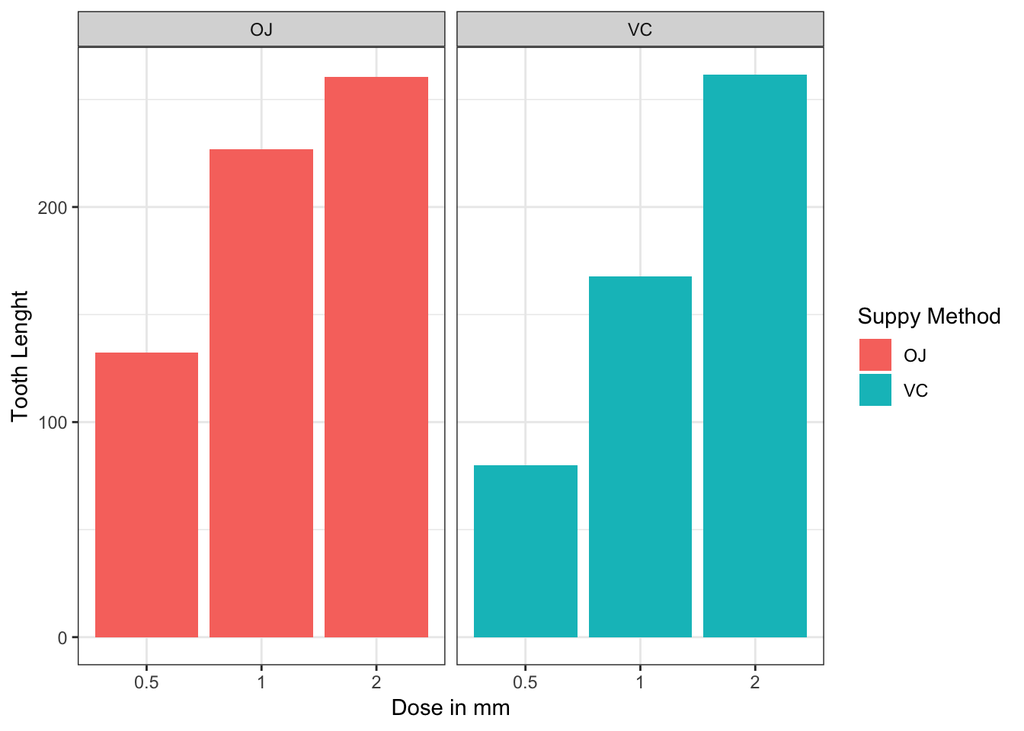

```r
ggplot(data,aes(factor(dose),y=len,fill=supp))+
  geom_col()+
  facet_wrap(~supp)+
  theme_bw()+
  labs(x="Dose in mm",y="Tooth Lenght",fill="Suppy Method")
```

From the plot it can be seen the dose seems to have an effect in the tooth groth. However, it is not clear that the supplement type have an effect.

### Hypothesis Testing

To compare the effect of the doses we will be using hypothesis testing between the three doses. First we have to filter the data by dose

```r
dose_0.5 <- data %>%
  filter(dose == 0.5)
dose_1 <- data %>%
  filter(dose == 1)
dose_2 <- data %>%
  filter(dose == 2)
#t-tes Between doses
t.test(dose_0.5$len,dose_1$len,paired = FALSE)
```

```
##
##  Welch Two Sample t-test
##
## data:  dose_0.5$len and dose_1$len
## t = -6.4766, df = 37.986, p-value = 1.268e-07
## alternative hypothesis: true difference in means is not equal to 0
## 95 percent confidence interval:
##  -11.983781  -6.276219
## sample estimates:
## mean of x mean of y
##    10.605    19.735
```

```r
t.test(dose_0.5$len,dose_2$len,paired = FALSE)
```

```
##
##  Welch Two Sample t-test
##
## data:  dose_0.5$len and dose_2$len
## t = -11.799, df = 36.883, p-value = 4.398e-14
## alternative hypothesis: true difference in means is not equal to 0
## 95 percent confidence interval:
##  -18.15617 -12.83383
## sample estimates:
## mean of x mean of y
##    10.605    26.100
```

```r
t.test(dose_1$len,dose_2$len,paired = FALSE)
```

```
##
##  Welch Two Sample t-test
##
## data:  dose_1$len and dose_2$len
## t = -4.9005, df = 37.101, p-value = 1.906e-05
## alternative hypothesis: true difference in means is not equal to 0
## 95 percent confidence interval:
##  -8.996481 -3.733519
## sample estimates:
## mean of x mean of y
##    19.735    26.100
```

From these results it can be infered that there is a significant difference between each on of the doses. The interval of confidence can be esay compute using conf

```r
t.test(dose_0.5$len,dose_1$len,paired = FALSE)$conf
```

```
## [1] -11.983781  -6.276219
## attr(,"conf.level")
## [1] 0.95
```

```r
t.test(dose_0.5$len,dose_2$len,paired = FALSE)$conf
```

```
## [1] -18.15617 -12.83383
## attr(,"conf.level")
## [1] 0.95
```

```r
t.test(dose_1$len,dose_2$len,paired = FALSE)$conf
```

```
## [1] -8.996481 -3.733519
## attr(,"conf.level")
## [1] 0.95
```

Now we can compare betwen supplement type. Since we have stablished that the dose has a significant effect, the suplement type will be compare for each of doses and not between them.

```r
vc_0.5 <- data %>%
  filter(dose == 0.5, supp =="VC")
vc_1 <- data %>%
  filter(dose == 1, supp =="VC")
vc_2 <- data %>%
  filter(dose == 2, supp =="VC")
oj_0.5 <- data %>%
  filter(dose == 0.5, supp =="OJ")
oj_1 <- data %>%
  filter(dose == 1, supp =="OJ")
oj_2 <- data %>%
  filter(dose == 2, supp =="OJ")
#Hypothesis testin
t.test(vc_0.5$len,oj_0.5$len,paired = FALSE)
```

```
##
##  Welch Two Sample t-test
##
## data:  vc_0.5$len and oj_0.5$len
## t = -3.1697, df = 14.969, p-value = 0.006359
## alternative hypothesis: true difference in means is not equal to 0
## 95 percent confidence interval:
##  -8.780943 -1.719057
## sample estimates:
## mean of x mean of y
##      7.98     13.23
```

```r
t.test(vc_1$len,oj_1$len,paired = FALSE)
```

```
##
##  Welch Two Sample t-test
##
## data:  vc_1$len and oj_1$len
## t = -4.0328, df = 15.358, p-value = 0.001038
## alternative hypothesis: true difference in means is not equal to 0
## 95 percent confidence interval:
##  -9.057852 -2.802148
## sample estimates:
## mean of x mean of y
##     16.77     22.70
```

```r
t.test(vc_2$len,oj_2$len,paired = FALSE)
```

```
##
##  Welch Two Sample t-test
##
## data:  vc_2$len and oj_2$len
## t = 0.046136, df = 14.04, p-value = 0.9639
## alternative hypothesis: true difference in means is not equal to 0
## 95 percent confidence interval:
##  -3.63807  3.79807
## sample estimates:
## mean of x mean of y
##     26.14     26.06
```

```r
# Confidence Intervals
t.test(vc_0.5$len,oj_0.5$len,paired = FALSE)$conf
```

```
## [1] -8.780943 -1.719057
## attr(,"conf.level")
## [1] 0.95
```

```r
t.test(vc_1$len,oj_1$len,paired = FALSE)$conf
```

```
## [1] -9.057852 -2.802148
## attr(,"conf.level")
## [1] 0.95
```

```r
t.test(vc_2$len,oj_2$len,paired = FALSE)$conf
```

```
## [1] -3.63807  3.79807
## attr(,"conf.level")
## [1] 0.95
```

From the result we can see that the supplmenet type has a signifcant effect for doses of 0.5 a 1 mg/day. In the case the 2 mg/day there is not change in the tooth growth by changing the supplment type.

### Conclusions

As conclusion the dose has a significant effect in the tooth growth. The confidence didn’t contain 0 and they were negative. This indicate that increase of doses yield greater growth.

In the case of the supplement type, the effect was just seen in the 0.5 and 1 mg.day dose. The intervals were negative, indicating that Orange Juice was a better delivery method. For the case of dose 2, there is not significant difference in the growth.